# Analysis on Election by Natutal and Enviroment Factors

chuyun shu cs3894

1/14/2021

# 1. Introduction & Access to ANES Data

The *American National Election Studies* (ANES) are surveys of voters in the U.S. on the national scale. For each presidential election since 1948, ANES collects responses from respondents both before and after the election. The goal of ANES is to understand political behaviors using systematic surveys. ANES’s data and results have been routinely used by news outlets, election campaigns and political researchers.

The *Time Series Cumulative Data* of ANES include answers, from respondents from different years, on selected questions that have been asked in three or more ANES’ *Time Series* studies. Tremendous amount of efforts have been put into data consolidation as variables are often named differently in different years.

# Section 2: Data Pre-processing

## Step 2.1: Checking `R` packages for data processing

From the packages’ descriptions:

`tidyverse` is an opinionated collection of R packages designed for data science. All packages share an underlying design philosophy, grammar, and data structures; `haven` enables `R` to read and write various data formats used by other statistical packages. `haven` is part of the `tidyverse`. `devtools` provides a collection of package development tools. `RColorBrewer` provides ready-to-use color palettes. `DT` provides an R interface to the JavaScript library DataTables; `ggplot2` a collection of functions for creating graphics, based on The Grammar of Graphics.

## Step 2.2: Import raw ANES data

```r
library(haven)
anes_dat <-
  read_sav("D:/CU--STAT--MA/GR 5243 Applied Data Science/project 1/Project1-RNotebook-master/doc/anes_timeseries_cdf.sav")

dim(anes_dat)
```

```
## [1] 59944  1029
```

Some basic data summaries: there are 59944 respondents and 1029 variables.

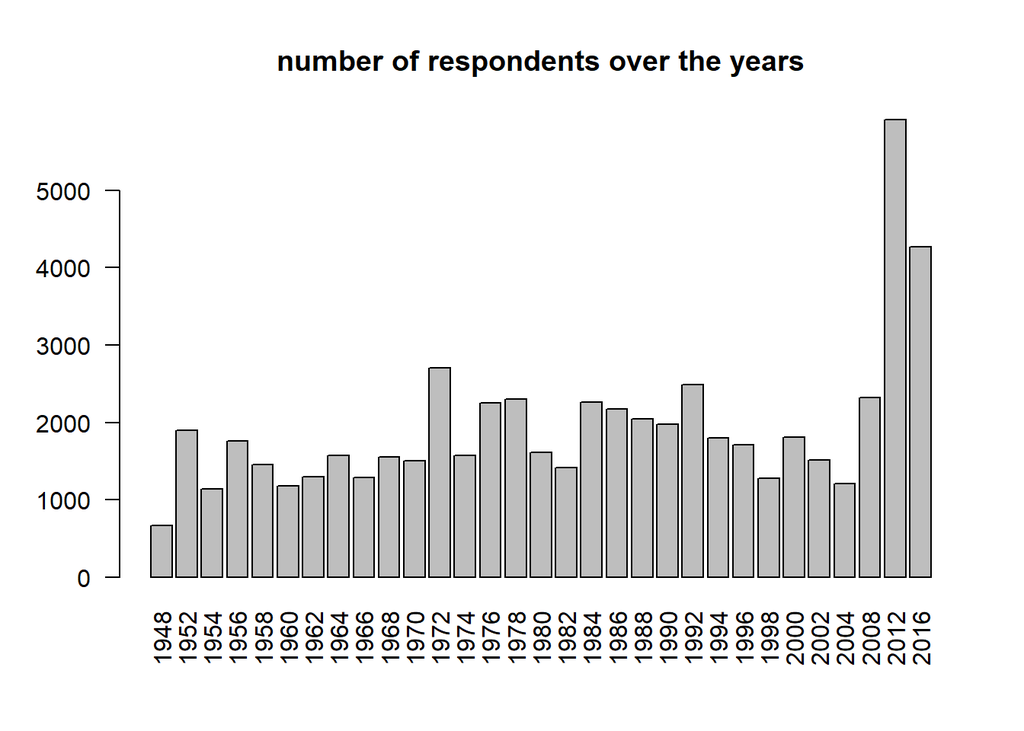

```r
barplot(table(anes_dat$VCF0004),
        las=2,
        main="number of respondents over the years")
```

Some variables are asked nearly all the years and some are asked only a few years.

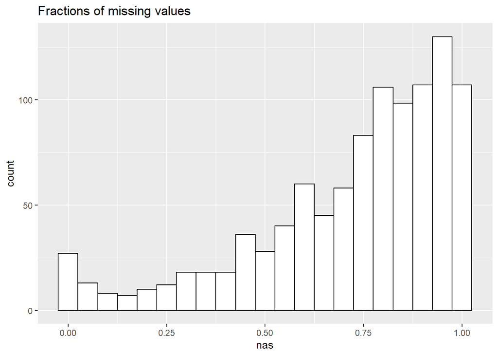

```r
anes_NAs=anes_dat%>%
  summarise_all(list(na.mean=function(x){
    mean(is.na(x))}))

anes_NAs=data.frame(nas=unlist(t(anes_NAs)))

ggplot(anes_NAs, aes(x=nas)) +
  geom_histogram(color="black",
                 fill="white",
                 binwidth=0.05)+
  labs(title="Fractions of missing values")
```

## Step 2.3: Process variables for analysis

```r
Election_years = as.character(seq(1952, 2016, 4))

anes_use = anes_dat %>%
  mutate(
    # demographic variables
    year = as_factor(VCF0004), #0
    #vote
    turnout = as_factor(VCF0703), #14038
    vote=as_factor(VCF0706),
    #environment factors
    education = as_factor(VCF0110), #591
    religion = as_factor(VCF0128), #333
    income = as_factor(VCF0114), #5449
    work = as_factor(VCF0151), #19454
    #natural factors
    gender = as_factor(VCF0104), #144
    race = as_factor(VCF0105a), #1540
    # active component variables
    meeting = as_factor(VCF0718), # 9076
    activities = as_factor(VCF0723), # 12258
    care = as_factor(VCF0311), #26115
    tv = as_factor(VCF0724), # 22561
    money = as_factor(VCF0742) # 27245
  ) %>%
  filter(year %in% Election_years)


anes_use <- anes_use %>% filter(!is.na(race)) %>% filter(!is.na(turnout)) %>% filter(!is.na(vote)) %>% filter(!is.na(education))%>%
  filter(!is.na(gender))%>% filter(!is.na(work))%>% filter(!is.na(income)) %>%filter(!is.na(religion))


library(data.table)

data.table(anes_use%>%
             select(year, turnout, vote, race, gender)%>%
             sample_n(30))
```

| year | turnout | vote | race | gender |
| --- | --- | --- | --- | --- |
| 1952 | 3. Voted (registered) | 2. Republican | 1. White non-Hispanic (1948-2012) | 1. Male |
| 1976 | 2. Registered, but did not vote | 7. Did not vote or voted but not for president (exc.1972) | 1. White non-Hispanic (1948-2012) | 2. Female |
| 1976 | 3. Voted (registered) | 2. Republican | 1. White non-Hispanic (1948-2012) | 2. Female |
| 1960 | 3. Voted (registered) | 2. Republican | 1. White non-Hispanic (1948-2012) | 2. Female |
| 1968 | 3. Voted (registered) | 2. Republican | 1. White non-Hispanic (1948-2012) | 2. Female |
| 1984 | 3. Voted (registered) | 1. Democrat | 1. White non-Hispanic (1948-2012) | 2. Female |
| 1984 | 3. Voted (registered) | 2. Republican | 1. White non-Hispanic (1948-2012) | 2. Female |
| 1984 | 3. Voted (registered) | 2. Republican | 1. White non-Hispanic (1948-2012) | 1. Male |
| 1992 | 3. Voted (registered) | 1. Democrat | 1. White non-Hispanic (1948-2012) | 1. Male |
| 1968 | 2. Registered, but did not vote | 7. Did not vote or voted but not for president (exc.1972) | 1. White non-Hispanic (1948-2012) | 1. Male |

[output cut: 20 more lines]

```r
anes_use <- anes_use %>%
select(year, turnout, vote, religion, income, work, education, race, gender, meeting, activities, care, tv, money)

save(anes_use, file="../output/data_use.RData")
```

# Section 3: Natural factors part: Analysis on Gender and Race.

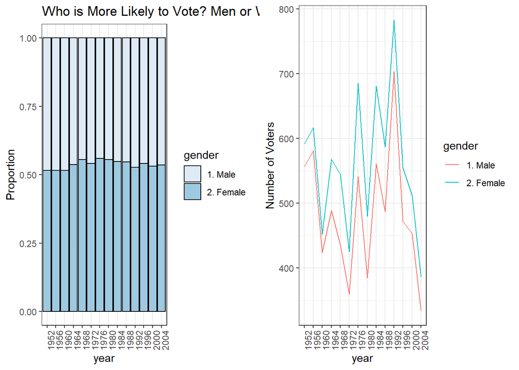

```r
library(cowplot)
library(ggpubr)

anes_gender <- anes_use %>%
                  filter(!is.na(gender) & turnout == "3. Voted (registered)") %>%
                  group_by(year, gender) %>%
                  count(turnout) %>%
                  group_by(year) %>%
                  mutate(prop = n/sum(n))

p1 <- anes_gender %>%
  ggplot(aes(x = year, y = prop, fill = gender)) +
  geom_bar(stat = "identity", colour = "black") +
  theme_bw()+
  theme(axis.text.x = element_text(angle = 90))+
  scale_fill_brewer(palette="Blues")+
  labs(title = "Who is More Likely to Vote? Men or Women?") +
  ylab("Proportion")

p2 <- anes_gender %>%
  ggplot(aes(x = year, y = n, group = gender, color = gender)) +
  geom_line() +
  theme_bw() +
  theme(axis.text.x = element_text(angle = 90)) +
  ylab("Number of Voters")

plot_grid(p1, p2)
```

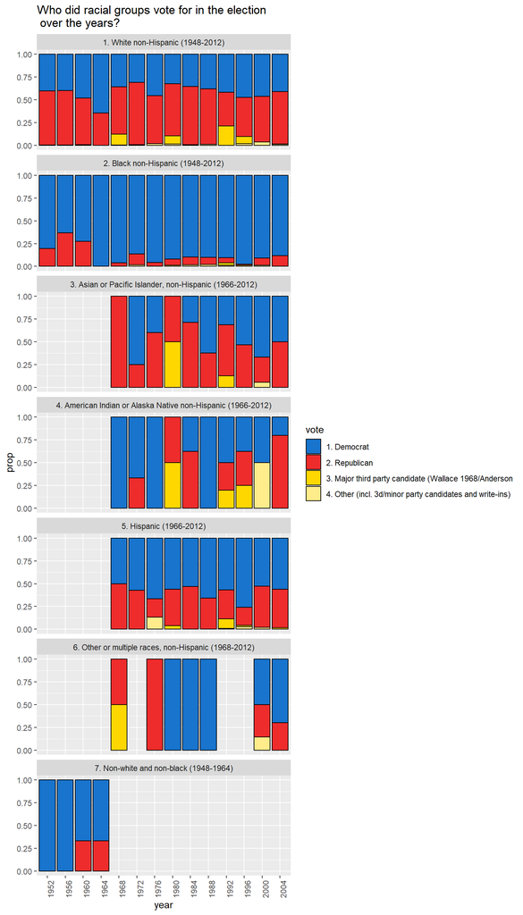

```r
anes_vote_race_year = anes_use %>%
  filter(!is.na(race) & !is.na(vote))%>%
  filter(vote!="7. Did not vote or voted but not for president (exc.1972)")%>%
  group_by(year, race)%>%
  count(vote)%>%
  group_by(year, race)%>%
  mutate(
    prop=n/sum(n)
  )
#%>%
#  filter(vote == "1. Democrat" | vote == "2. Republican")

ggplot(anes_vote_race_year,
       aes(x=year, y=prop, fill=vote)) +
  geom_bar(stat="identity", colour="black")+
  scale_fill_manual(values=c("dodgerblue3", "firebrick2", "gold1", "lightgoldenrod1"))+
  facet_wrap(~race, ncol=1) +
  theme(axis.text.x = element_text(angle = 90))+
  labs(title="Who did racial groups vote for in the election \n over the years?")
```

# Section 4: Enviroment factors part: Analysis on Religion, Education and work.

## 4.1 Who did they vote for in the election?

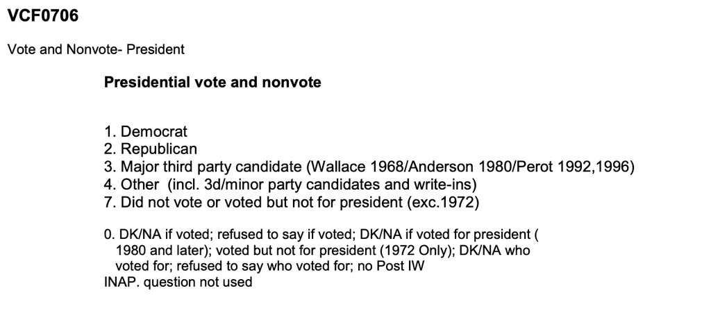

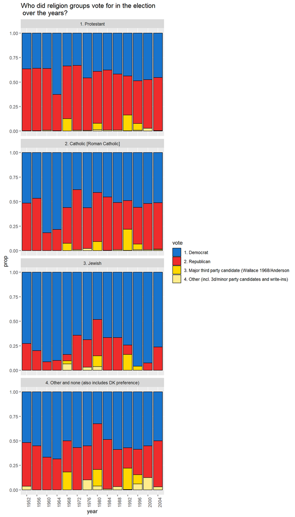

```r
anes_vote_religion_year = anes_use %>%
  filter(!is.na(religion) & !is.na(vote))%>%
  filter(vote!="7. Did not vote or voted but not for president (exc.1972)")%>%
  group_by(year, religion)%>%
  count(vote)%>%
  group_by(year, religion)%>%
  mutate(
    prop=n/sum(n)
  )
#%>%
#  filter(vote == "1. Democrat" | vote == "2. Republican")

ggplot(anes_vote_religion_year,
       aes(x=year, y=prop, fill=vote)) +
  geom_bar(stat="identity", colour="black")+
  scale_fill_manual(values=c("dodgerblue3", "firebrick2", "gold1", "lightgoldenrod1"))+
  facet_wrap(~religion, ncol=1) +
  theme(axis.text.x = element_text(angle = 90))+
  labs(title="Who did religion groups vote for in the election \n over the years?")
```

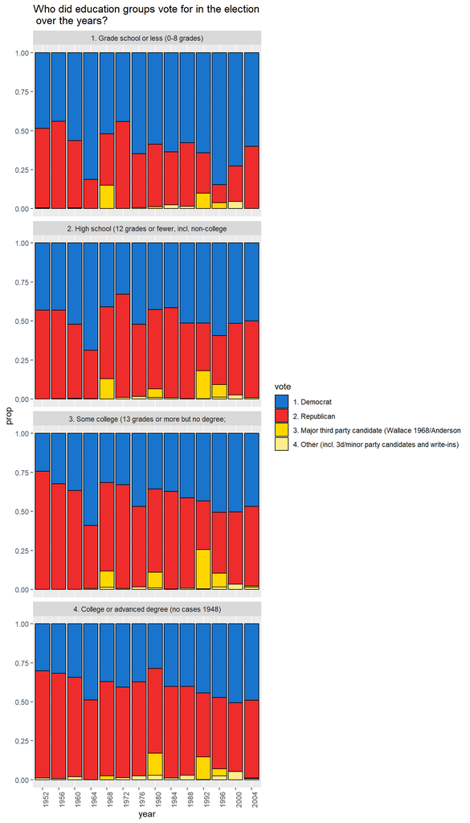

```r
anes_vote_education_year = anes_use %>%
  filter(!is.na(education) & !is.na(vote))%>%
  filter(vote!="7. Did not vote or voted but not for president (exc.1972)")%>%
  group_by(year, education)%>%
  count(vote)%>%
  group_by(year, education)%>%
  mutate(
    prop=n/sum(n)
  )
#%>%
#  filter(vote == "1. Democrat" | vote == "2. Republican")

ggplot(anes_vote_education_year,
       aes(x=year, y=prop, fill=vote)) +
  geom_bar(stat="identity", colour="black")+
  scale_fill_manual(values=c("dodgerblue3", "firebrick2", "gold1", "lightgoldenrod1"))+
  facet_wrap(~education, ncol=1) +
  theme(axis.text.x = element_text(angle = 90))+
  labs(title="Who did education groups vote for in the election \n over the years?")
```

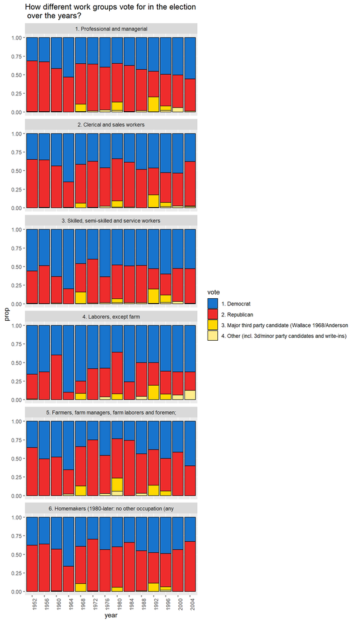

```r
anes_vote_work_year = anes_use %>%
  filter(!is.na(work) & !is.na(vote))%>%
  filter(vote!="7. Did not vote or voted but not for president (exc.1972)")%>%
  group_by(year, work)%>%
  count(vote)%>%
  group_by(year, work)%>%
  mutate(
    prop=n/sum(n)
  )
#%>%
#  filter(vote == "1. Democrat" | vote == "2. Republican")

ggplot(anes_vote_work_year,
       aes(x=year, y=prop, fill=vote)) +
  geom_bar(stat="identity", colour="black")+
  scale_fill_manual(values=c("dodgerblue3", "firebrick2", "gold1", "lightgoldenrod1"))+
  facet_wrap(~work, ncol=1) +
  theme(axis.text.x = element_text(angle = 90))+
  labs(title="How different work groups vote for in the election \n over the years?")
```

# Conclusion